# Exhaustive Search - CV and AIC

Cesare Miglioli

10 March 2022

## 1) Simulations and CV

### a) Generate from a MVN (multivariate normal) a matrix $\mathbf{X_{n*p}}$ with $n = 1000$ and $p = 5$. You can choose the location vector as you wish but set the scale matrix as the identity.

```r
n <- 1000

p <- 5

rho <- 0

mu <- rep(1,p)

sigma <- rep(0,p^2)

sigma <- matrix(data = sigma, ncol = p,nrow = p)

# Autoregressive structure

for (i in 1:p) {

  for (j in 1:p) {


    sigma[i,j] <- rho^(abs(i-j))


  }


}

set.seed(123)

X <- mvrnorm(n,mu,sigma)
```

### b) Choose the generating vector $\boldsymbol{\beta }= [3 \; 1.5 \; 0 \; 2 \; 0]$ and retrieve the signal to noise ratio of this setting.

There are several definitions of the signal to noise ratio (SNR) usually context-dependent but for this practical we will focus on two of them. In physics, the SNR can be defined as the reciprocal of the coefficient of variation, i.e., the ratio of mean to standard deviation of a signal or measurement: $SNR_{1} = \frac{\mu}{\sigma}$ where $\mu$ is the signal mean or expected value and $\sigma$ is the standard deviation of the noise. In statistics usually, given a model $y = f(X) + \epsilon$, we define the SNR as the ratio between the variance of the data and the variance of the noise: $SNR_{2} = \frac{Var(f(X))}{Var(\epsilon)}$. In the context of our simulation study then we have that: $SNR_{1} = \frac{E[x^{T}\beta]}{\sqrt{Var(\epsilon)}} = \mu^{T}\beta$ while $SNR_{2} = \frac{Var(x^{T}\beta)}{Var(\epsilon)} = \beta^{T}\beta$. It is clear that, in our setting, the second definition is the more appropriate one as, for example, we could have a negative SNR depending on the values of the location vector and the beta coefficients.

```r
beta <- c(3,1.5,0,2,0)

# Signal to noise ratio:

# first definition

s_n_r_1 <- t(mu)%*%beta

# second definition (preferred)

s_n_r_2 <- beta%*%beta

#Note well: sigma in our case is set to one (see point c)
```

### c) Generate the responses thanks to the relation $\mathbf{y} = \mathbf{X_{n*p}} \; \boldsymbol{\beta} + \boldsymbol{\epsilon}$ where $\epsilon_{i}$ is a standard normal. Suppose for simplicity that the errors are uncorrelated.

```r
eps <- rnorm(n,0,1)

y <- X%*%beta + eps
```

### d) Split the data randomly in two halves (k=2) and use one half as a training set to determine $\boldsymbol{\hat{\beta}_{MLE}}$. Then, making use of the specific loss function of the linear regression, find the test set cross validation error for each possible model with the other half. Repeat the procedure switching training and test set. Conclude on the best model by averaging the cross validation errors in the two data halves for each possible model.

In our case since $p=5$, we have $2^p - 1 = 31$ possible models to check.

```r
set.seed(123)

index <- sample(1:n, size=0.5*n,replace = F)

# Split data
y_train<- y[-index,]
x_train<- X[-index,]
y_test<- y[index,]
x_test<-X[index,]

# Create a list with all the possible models

v <- c(1,2,3,4,5) #variable index

res <- do.call("c", lapply(seq_along(v), function(i) combn(v, i, FUN = list)))

cv_err <- matrix(data = rep(0,2*length(res)),nrow = length(res),ncol = 2)

for (i in 1:length(res)) {

  df_train <- data.frame(y_train,x_train[,res[[i]]])

  df_test <- data.frame(y_test,x_test[,res[[i]]])

  m_train <- lm(df_train$y_train ~ .-1, data = df_train)

  m_test <- lm(df_test$y_test ~ .-1, data = df_test)

  cv_err[i,1] <- t(y_test - as.matrix(x_test[,res[[i]]])%*%as.vector(m_train$coefficients))%*%
    (y_test - as.matrix(x_test[,res[[i]]])%*%as.vector(m_train$coefficients))

  cv_err[i,2] <- t(y_train - as.matrix(x_train[,res[[i]]])%*%as.vector(m_test$coefficients))%*%
    (y_train - as.matrix(x_train[,res[[i]]])%*%as.vector(m_test$coefficients))

}

best_mod_cv <- res[[which.min(rowMeans(cv_err))]]

best_mod_cv
```

```
## [1] 1 2 3 4
```

If $p=100$ then we know that there are $2^{100} - 1$ possible model. This is in the $O(10^{30})$ possible models. If we make the hypothesis that each model can be computed in $1$ second then, since in one year we have $31.536.000$ seconds, we are in the $O(10^{22})$ years!

```r
# Time evaluation

require(tictoc)

tic()

#type here results at point d) to evaluate the time

Sys.sleep(1)
toc()
```

## 2) Simulations and AIC

In this exercise we would like to repeat the steps underlined above in the specific case of the Akaike information criterion.

### a) Retrieve the values found up to point (c) of exercise 1.

### b) Calculate the AIC for all possible models when $p = 5$ without using the predefined function present in R. Conclude on the best model.

### c) As for the previous exercise, suppose now that we increase the size of $\boldsymbol{\beta }$ to 100 (i.e. $p = 100$). Conclude on the feasibility of the task.

```r
# a) I will use the same X and y generated for the CV case.

# b)

aic_val <- rep(0,length(res))

for (i in 1:length(res)) {

  df <- data.frame(y,X[,res[[i]]])

  mod <- lm(df$y ~ .-1, data = df)

  aic_val[i] <- -2*logLik(mod) + 2*(length(res[[i]])+1)

}

best_mod_aic <- res[[which.min(aic_val)]]

best_mod_aic
```

```
## [1] 1 2 4
```

```r
# c) The same reasoning done for CV holds also here. Calculating the AIC is faster than CV but it would not impact the amount of time required for an exhaustive search which still remains unfeasible.
```

```r
n_sim <- 100

exact <- matrix(data = 2*rep(0,n_sim),nrow = n_sim,ncol = 2)

correct <- matrix(data = 2*rep(0,n_sim),nrow = n_sim,ncol = 2)

average <- matrix(data = 2*rep(0,n_sim),nrow = n_sim,ncol = 2)

truth <- c(1,2,4)

for (j in 1:n_sim) {

set.seed(j)

eps <- rnorm(n,0,1)

y <- X%*%beta + eps

# Split data
y_train<- y[-index,]
x_train<- X[-index,]
y_test<- y[index,]
x_test<-X[index,]

cv_err <- matrix(data = rep(0,2*length(res)),nrow = length(res),ncol = 2)

aic_val <- rep(0,length(res))

for (i in 1:length(res)) {

  df_train <- data.frame(y_train,x_train[,res[[i]]])

  df_test <- data.frame(y_test,x_test[,res[[i]]])

  m_train <- lm(df_train$y_train ~ .-1, data = df_train)

  m_test <- lm(df_test$y_test ~ .-1, data = df_test)

  cv_err[i,1] <- t(y_test - as.matrix(x_test[,res[[i]]])%*%as.vector(m_train$coefficients))%*%
    (y_test - as.matrix(x_test[,res[[i]]])%*%as.vector(m_train$coefficients))

  cv_err[i,2] <- t(y_train - as.matrix(x_train[,res[[i]]])%*%as.vector(m_test$coefficients))%*%
    (y_train - as.matrix(x_train[,res[[i]]])%*%as.vector(m_test$coefficients))

  df <- data.frame(y,X[,res[[i]]])

  mod <- lm(df$y ~ .-1, data = df)

  aic_val[i] <- -2*logLik(mod) + 2*(length(res[[i]])+1)

}

best_mod_cv <- res[[which.min(rowMeans(cv_err))]]

best_mod_aic <- res[[which.min(aic_val)]]

exact[j,] <- c(identical(best_mod_cv,truth),identical(best_mod_aic,truth))

correct[j,] <- c(all(truth %in% best_mod_cv),all(truth %in% best_mod_aic))

average[j,] <- c(length(best_mod_cv),length(best_mod_aic))

}

# CV

cv_e <- sum(exact[,1])/n_sim

cv_c <- sum(correct[,1])/n_sim

cv_a <- mean(average[,1])

c(cv_e, cv_c, cv_a)
```

```
## [1] 0.49 1.00 3.58
```

```r
# AIC

aic_e <- sum(exact[,2])/n_sim

aic_c <- sum(correct[,2])/n_sim

aic_a <- mean(average[,2])

c(aic_e, aic_c,aic_a)
```

```
## [1] 0.69 1.00 3.32
```

AIC is a parametric model selection criterion so when the model is correct (as in this case) it is designed to target the right quantity. On the other hand CV is non parametric thus inferior by construction in this setting. In real applications you should remember that our model assumption may not be met.

## 3) Real Data Application (optional: does not count for the grade)

Load the dataset (see exercise 3 of Practical 1 for further info) and perform an exhaustive search on the continuous covariates (i.e. avoiding factors) based on CV and AIC in order to find the best model.\

```r
data_zambia <- readRDS('malnutrion_zambia_cleaned.rds')

data_zambia <- data_zambia[,c(1:7,21,22,24)] #exclude the factors from the analysis

### Exhaustive search with leaps (AIC case) ###

require(leaps)
regsubsets.out <- regsubsets(data_zambia$`Height for age sd` ~ .,data = data_zambia,nbest = 1,
                             nvmax = NULL,    # NULL for no limit on number of variables
                             force.in = NULL, force.out = NULL,method = "exhaustive")

summary(regsubsets.out)
```

```
## Subset selection object
## Call: regsubsets.formula(data_zambia$`Height for age sd` ~ ., data = data_zambia,
##     nbest = 1, nvmax = NULL, force.in = NULL, force.out = NULL,
##     method = "exhaustive")
## 9 Variables  (and intercept)
##                                   Forced in Forced out
## `Breastfeeding duration (months)`     FALSE      FALSE
## `Age of the child (months)`           FALSE      FALSE
## `Age of the mother (years)`           FALSE      FALSE
## `BMI mother`                          FALSE      FALSE
## `Heigth mother (meter)`               FALSE      FALSE
## `Weight mother (kg)`                  FALSE      FALSE
## `Wealth index factor score`           FALSE      FALSE
## `Child weight at birth (kg)`          FALSE      FALSE
## `Interval between births`             FALSE      FALSE
## 1 subsets of each size up to 9
## Selection Algorithm: exhaustive
##          `Breastfeeding duration (months)` `Age of the child (months)`
## 1  ( 1 ) "*"                               " "
## 2  ( 1 ) "*"                               " "
## 3  ( 1 ) "*"                               " "
## 4  ( 1 ) "*"                               " "
## 5  ( 1 ) "*"                               " "
## 6  ( 1 ) "*"                               " "
## 7  ( 1 ) "*"                               "*"
## 8  ( 1 ) "*"                               "*"
## 9  ( 1 ) "*"                               "*"
##          `Age of the mother (years)` `BMI mother` `Heigth mother (meter)`
## 1  ( 1 ) " "                         " "          " "
## 2  ( 1 ) " "                         " "          "*"
## 3  ( 1 ) " "                         " "          "*"
## 4  ( 1 ) " "                         " "          "*"
## 5  ( 1 ) " "                         "*"          " "
## 6  ( 1 ) "*"                         "*"          " "
## 7  ( 1 ) "*"                         "*"          " "
## 8  ( 1 ) "*"                         "*"          " "
## 9  ( 1 ) "*"                         "*"          "*"
##          `Weight mother (kg)` `Wealth index factor score`
## 1  ( 1 ) " "                  " "
## 2  ( 1 ) " "                  " "
## 3  ( 1 ) " "                  " "
## 4  ( 1 ) " "                  "*"
## 5  ( 1 ) "*"                  "*"
## 6  ( 1 ) "*"                  "*"
## 7  ( 1 ) "*"                  "*"
## 8  ( 1 ) "*"                  "*"
## 9  ( 1 ) "*"                  "*"
##          `Child weight at birth (kg)` `Interval between births`
## 1  ( 1 ) " "                          " "
## 2  ( 1 ) " "                          " "
## 3  ( 1 ) "*"                          " "
## 4  ( 1 ) "*"                          " "
## 5  ( 1 ) "*"                          " "
## 6  ( 1 ) "*"                          " "
## 7  ( 1 ) "*"                          " "
## 8  ( 1 ) "*"                          "*"
## 9  ( 1 ) "*"                          "*"
```

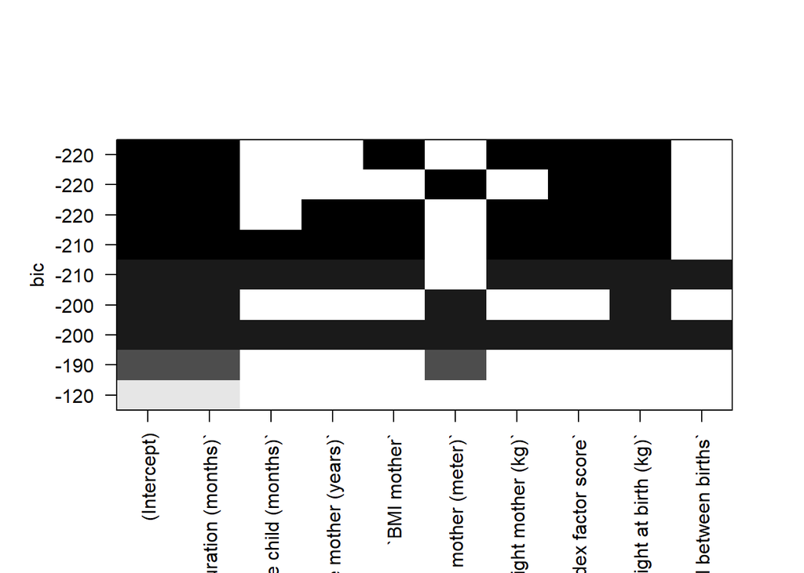

```r
plot(regsubsets.out) # BIC is default
```

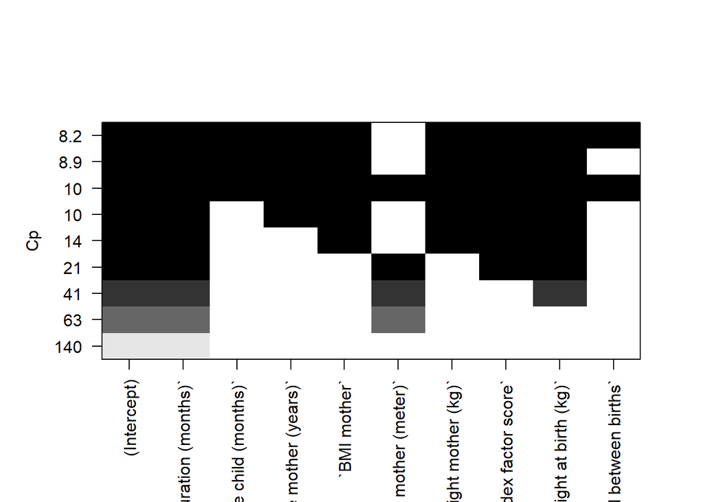

```r
plot(regsubsets.out,scale = "Cp") #C_p case which is equivalent to AIC with a linear model

# Other packages for model selection

### MumIn (AICc case) ###

require(MuMIn)
```

```r
data_model <- lm(data_zambia$`Height for age sd` ~ .,data = data_zambia,na.action = "na.fail")

combinations <- dredge(data_model) #AICc search

### caret (CV case and AIC case) ###

require(caret)
attach(data_zambia)

# Unfortunately there is no exhaustive search based on CV in Caret, it is just stepwise.


#setting up 10-fold cross-validation


control <- trainControl(method="cv", number=10)


#finding the ideal model by AIC criterion


model_AIC <- train(`Height for age sd`~.,data=data_zambia,method="lmStepAIC",trControl=control)
```

[output not shown]

[output cut: 410 more lines]

[output not shown]

```r
#finding the ideal model by mean square error


modelCV <- train(`Height for age sd`~.,data=data_zambia,method="lm",trControl=control)


detach(data_zambia)


# In order to do a full exhaustive search with CV, we should exploit the codes produced in exercise 1. Of course as the number of variables increase, the task becomes impossible.


### Also glmulti package maybe used for the same purposes. Look at the function glmulti() for further information. ###
```